# hw_1

## Problem set 1, Intro to NLP 2018

#### This is due on September 25, 2018, submitted electronically. 100 points total.

##### How to do this problem set:

- What version of Python should I use? 3.6!
- Most of these questions require writing Python code and computing results, and the rest of them have textual answers. To generate the answers, you will have to fill out a supporting file, `hw1.py`.
- For all of the textual answers you have to fill out have placeholder text which says "Answer in one or two sentences here." For each question, you need to replace "Answer in one or two sentences here" with your answer.
- Write all the answers in this ipython notebook. Once you are finished (1) Generate a PDF via (File -> Download As -> PDF) and upload to Gradescope (2)Turn in `hw_1.py` and `hw_1.ipynb` on Moodle.
- **Important** check your PDF before you turn it in to gradescope to make sure it exported correctly. If ipython notebook gets confused about your syntax it will sometimes terminate the PDF creation routine early. If your whole PDF does not print, try running `$jupyter nbconvert --to pdf 2018hw1.ipynb` to identify and fix any syntax errors that might be causing problems
- When creating your final version of the PDF to hand in, please do a fresh restart and execute every cell in order. Then you'll be sure it's actually right. One handy way to do this is by clicking `Cell -> Run All` in the notebook menu.
- This assignment is designed so that you can run all cells in a few minutes of computation time. If it is taking longer than that, you probably have made a mistake in your code.

##### Academic honesty

- We will audit the Moodle code from a set number of students, chosen at random. The audits will check that the code you wrote and turned on Moodle generates the answers you turn in on your PDF. If you turn in correct answers on your PDF without code that actually generates those answers, we will consider this a serious case of cheating. See the course page for honesty policies.
- We will also run automatic checks of code on Moodle for plagiarism. Copying code from others is also considered a serious case of cheating.

```python
# Run this cell! It sets some things up for you.

# This code makes plots appear inline in this document rather than in a new window.
import matplotlib.pyplot as plt
from __future__ import division  # this line is important to avoid unexpected behavior from division

# This code imports your work from hw_1.py
from hw_1 import *

%matplotlib inline
plt.rcParams['figure.figsize'] = (5, 4) # set default size of plots

# Some more magic so that the notebook will reload external python modules;
# see http://stackoverflow.com/questions/1907993/autoreload-of-modules-in-ipython
%load_ext autoreload
%autoreload 2
```

```
The autoreload extension is already loaded. To reload it, use:
  %reload_ext autoreload
```

```python
# download the IMDB large movie review corpus from https://people.cs.umass.edu/~miyyer/cs585/homeworks/data/large_movie_review_dataset.zip to a file location on your computer

PATH_TO_DATA = 'large_movie_review_dataset'  # set this variable to point to the location of the IMDB corpus on your computer
POS_LABEL = 'pos'
NEG_LABEL = 'neg'
TRAIN_DIR = os.path.join(PATH_TO_DATA, "train")
TEST_DIR = os.path.join(PATH_TO_DATA, "test")

for label in [POS_LABEL, NEG_LABEL]:
    if len(os.listdir(TRAIN_DIR + "/" + label)) == 12500:
        print ("Great! You have 12500 {} reviews in {}".format(label, TRAIN_DIR + "/" + label))
    else:
        print ("Oh no! Something is wrong. Check your code which loads the reviews")
```

```
Great! You have 12500 pos reviews in large_movie_review_dataset\train/pos
Great! You have 12500 neg reviews in large_movie_review_dataset\train/neg
```

```python
# Actually reading the data you are working with is an important part of NLP! Let's look at one of these reviews

print (open(TRAIN_DIR + "/neg/98_1.txt").read())
```

[output not shown]

## Part One: Intro to NLP in Python: types, tokens and Zipf's law

#### Types and tokens

One major part of any NLP project is word tokenization. Word tokenization is the task of segmenting text into individual words, called tokens. In this assignment, we will use simple whitespace tokenization. Take a look at the `tokenize_doc` function in `hw_1.py`. **You should not modify tokenize_doc** but make sure you understand what it is doing.

```python
# We have provided a tokenize_doc function in hw_1.py. Here is a short demo of how it works

d1 = "This SAMPLE doc has   words tHat  repeat repeat"
bow = tokenize_doc(d1)

assert bow['this'] == 1
assert bow['sample'] == 1
assert bow['doc'] == 1
assert bow['has'] == 1
assert bow['words'] == 1
assert bow['that'] == 1
assert bow['repeat'] == 2

bow2 = tokenize_doc("CMPSCI 585 is already my favorite class this semester!")
for b in bow2:
    print (b)
```

```
cmpsci
585
is
already
my
favorite
class
this
semester!
```

Now we are going to look at the word types and word tokens in the corpus. Use the `word_counts` dictionary variable to store the count of each word in the corpus. Use the `tokenize_doc` function to break documents into tokens. **You should not modify tokenize_doc** but make sure you understand what it is doing.

**Question 1.1 (5 points)**

Complete the cell below to fill out the `word_counts` dictionary variable. `word_counts` keeps track of how many times a word type appears across the corpus. For instance, `word_counts["movie"]` should store the number 61492 -- the count of how many times the word `movie` appears in the corpus.

```python
import glob
import codecs
word_counts = Counter() # Counters are often useful for NLP in python

for label in [POS_LABEL, NEG_LABEL]:
    for directory in [TRAIN_DIR, TEST_DIR]:
        for fn in glob.glob(directory + "/" + label + "/*txt"):
            doc = codecs.open(fn, 'r', 'utf8') # Open the file with UTF-8 encoding
            ## TODO: complete me!
            tokens= tokenize_doc(doc.read())
            for i in tokens.keys():
                word_counts[i]+=tokens[i]
```

```python
# you should see 61492 instances of the word type "movie" in the corpus.
if word_counts["movie"] == 61492:
    print ("yay! there are {} total instances of the word type movie in the corpus".format(word_counts["movie"]))
else:
    print ("hmm. Something seems off. Double check your code")
```

```
yay! there are 61492.0 total instances of the word type movie in the corpus
```

**Question 1.2 (5 points)**

Take a look at the following values:

```python
print ("there are {} word types in the corpus".format(n_word_types(word_counts)))
print ("there are {} word tokens in the corpus".format(n_word_tokens(word_counts)))
```

```
there are 390931 word types in the corpus
there are 11557847 word tokens in the corpus
```

You should see a much higher number of tokens than types. Why is that?

*A word type is like a key in that it is unique throughout the corpus, however the word tokens may count multiple occurences of a word type in the corpus hence, the number of tokens is vastly superior.*

**Question 1.3 (5 points)**

Using the word_counts dictionary you just created, make a new dictionary called sorted_dict where the words are sorted according to their counts, in decending order:

```python
# Implement me!
sorted_dict= word_counts.most_common()
```

Now print the first 30 values from sorted_dict.

```python
# Implement me!
print (sorted_dict[:30])
```

[output not shown]

#### Zipf's Law

**Question 1.4 (5 points)**

In this section, you will verify a key statistical properties of text: [Zipf's Law](https://en.wikipedia.org/wiki/Zipf%27s_law).

Zipf's Law describes the relations between the frequency rank of words and frequency value of words. For a word $w$, its frequency is inversely proportional to its rank:

$$count_w = K \frac{1}{rank_w}$$

or in other words $$\log(count_w) = K - \log(rank_w)$$

for some constant $K$, specific to the corpus and how words are being defined.

Therefore, if Zipf's Law holds, after sorting the words descending on frequency, word frequency decreases in an approximately linear fashion under a log-log scale.

Please make such a log-log plot by ploting the rank versus frequency **Hint: Make use of the sorted dictionary you just created.**. Use a scatter plot where the x-axis is the *log(rank)*, and y-axis is *log(frequency)*. You should get this information from `word_counts`; for example, you can take the individual word counts and sort them. dict methods `.items()` and/or `values()` may be useful. (Note that it doesn't really matter whether ranks start at 1 or 0 in terms of how the plot comes out.) You can check your results by comparing your plots to ones on Wikipedia; they should look qualitatively similar.

*Please remember to label the meaning of the x-axis and y-axis.*

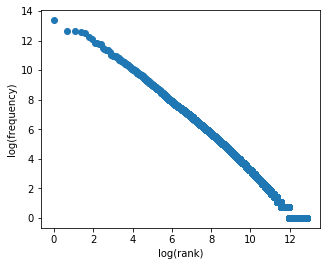

```python
import math
import operator
x = []
y = []
X_LABEL = "log(rank)"
Y_LABEL = "log(frequency)"

# implement me! you should fill the x and y arrays. Add your code here
rank=1
for i in sorted_dict:
    x.append(math.log(rank))
    y.append(math.log(i[1]))
    rank+=1
plt.scatter(x, y)
plt.xlabel(X_LABEL)
plt.ylabel(Y_LABEL)
```

**Question 1.5 (5 points)**

You should see some discontinuities on the left and right sides of this figure. Why are we seeing them on the left? Why are we seeing them on the right? On the right, what are those "ledges"?

*These discontinuities appear because of the vast difference in frequency of some of the words. At high ranks, we have rare, infrequent words hence the discrepancies on the right. On the left however, words like 'the' appear almost twice more than the next most frequent word 'a', hence the discrepancy. The ledges on the right are all the words which exist only once since log(1) =0.*

## Part Two: Naive Bayes

This section of the homework will walk you through coding a Naive Bayes classifier that can distinguish between positive and negative reviews (at some level of accuracy).

**Question 2.1 (10 pts)**

To start, implement the `update_model` function in `hw1.py`. Make sure to read the function comments so you know what to update. Also review the NaiveBayes class variables in the `def __init__` method of the NaiveBayes class to get a sense of which statistics are important to keep track of. Once you have implemented `update_model`, run the train model function using the code below. What is the size of the vocabulary used in the training documents? You’ll need to provide the path to the dataset you downloaded to run the code.

```python
nb = NaiveBayes(PATH_TO_DATA, tokenizer=tokenize_doc)
nb.train_model()


if len(nb.vocab) == 251637:
    print ("Great! The vocabulary size is {}".format(251637))
else:
    print ("Oh no! Something seems off. Double check your code before continuing. Maybe a mistake in update_model?")
```

```
REPORTING CORPUS STATISTICS
NUMBER OF DOCUMENTS IN POSITIVE CLASS: 12500.0
NUMBER OF DOCUMENTS IN NEGATIVE CLASS: 12500.0
NUMBER OF TOKENS IN POSITIVE CLASS: 2958832.0
NUMBER OF TOKENS IN NEGATIVE CLASS: 2885848.0
VOCABULARY SIZE: NUMBER OF UNIQUE WORDTYPES IN TRAINING CORPUS: 251637
Great! The vocabulary size is 251637
```

#### Exploratory analysis

Let’s begin to explore the count statistics stored by the update model function. Implement the provided `top_n` function to find the top 10 most common words in the positive class and top 10 most common words in the negative class.

```python
print ("TOP 10 WORDS FOR CLASS " + POS_LABEL + ":")
for tok, count in nb.top_n(POS_LABEL, 10):
    print ('', tok, count)
print ()

print ("TOP 10 WORDS FOR CLASS " + NEG_LABEL + ":")
for tok, count in nb.top_n(NEG_LABEL, 10):
    print ('', tok, count)
print ()
```

```
TOP 10 WORDS FOR CLASS pos:
 the 165805.0
 and 87029.0
 a 82055.0
 of 76155.0
 to 65869.0
 is 55785.0
 in 48422.0
 i 33143.0
 it 32802.0
 that 32705.0

TOP 10 WORDS FOR CLASS neg:
 the 156393.0
 a 77898.0
 and 71543.0
 of 68307.0
 to 68098.0
 is 48386.0
 in 42105.0
 i 37337.0
 this 37301.0
 that 33587.0
```

**Question 2.2 (5 points)**

What is the first thing that you notice when you look at the top 10 words for the 2 classes? Are these words helpful for discriminating between the two classes? Do you think this trend carries forward to other texts from the English language? What about other languages?

*They are all pretty much the same words. They're not really helpful in being able to tell the two classes apart. This trend will be visible in other English texts as well as all of the above words are common prepositions used to connect words together and form the basic foundation of sentences. These types are present in other languages and scripts as well as they are the building blocks of any language structure.*

**Question 2.3 (10 pts)**

The Naive Bayes model assumes that all features are conditionally independent given the class label. For our purposes, this means that the probability of seeing a particular word in a document with class label $y$ is independent of the rest of the words in that document. Implement the `p_word_given_label` function. This function calculates P (w|y) (i.e., the probability of seeing word w in a document given the label of that document is y).

Use your `p_word_given_label` function to compute the probability of seeing the word “amazing” given each sentiment label. Repeat the computation for the word “dull.”

```python
print ("P('amazing'|pos):",  nb.p_word_given_label("amazing", POS_LABEL))
print ("P('amazing'|neg):",  nb.p_word_given_label("amazing", NEG_LABEL))
print ("P('dull'|pos):",  nb.p_word_given_label("dull", POS_LABEL))
print ("P('dull'|neg):",  nb.p_word_given_label("dull", NEG_LABEL))
```

```
P('amazing'|pos): 0.00026158970837141145
P('amazing'|neg): 7.207586816769282e-05
P('dull'|pos): 3.278320634628799e-05
P('dull'|neg): 0.00014311218054450546
```

Which word has a higher probability, given the positive class? Which word has a higher probability, given the negative class? Is this behavior expected?

*'Amazing' has a higher probability given the positive class while 'dull' has the higher probability given the negative class. Yes, this behaviour is the expected outcome.*

What is the purpose of the independence assumption for the Naive Bayes classifier?

*It basically means that each input we put into the model gets assumed that it doesn't depend on the other inputs. If it did, it would skew the results considering all the extra dependencies and probabilities that would have to be computed which for a decently sized list would become extremely long, tedious and cause overflow. In the case for an unconditional independence, the model may tend to find strong correlation between unrelated words. Hence, a conditional independence is reasonable as the depndence amongst features can be explained by an underlying class.*

**Question 2.4 (5 pts)**

In the next cell, compute the probability of the word "stop-sign." in the positive training data and negative training data.

```python
print ("P('stop-sign.'|pos):",  nb.p_word_given_label("stop-sign.", POS_LABEL))
print ("P('stop-sign.'|neg):",  nb.p_word_given_label("stop-sign.", NEG_LABEL))
```

```
P('stop-sign.'|pos): 0.0
P('stop-sign.'|neg): 3.4651859696006166e-07
```

What is unusual about P('stop-sign.'|pos)? Why is this a problem?

*It states that the probability of 'stop-sign.' given a positive class is 0. This is a problem because if the probability of a word is 0, then it's chance of existing is 0 i.e. it is impossible. So for any test data that we choose to analyse later on, this word would never exist in any of those datasets which is blatantly wrong. However rare the word, there is always a chance, albeit miniscule, of it occurring which means probability should atleast be greater than 0. It will also cause a problem for other results as when we multiply the probability with other, it would make the result 0 as well or the log infinitely high.*

**Question 2.5 (5 pts)**

We can address the issues from question 2.4 with add-$\alpha$ smoothing (like add-1 smoothing except instead of adding 1 we add $\alpha$). Implement `p_word_given_label_and_alpha` and then run the next cell. Hint: look at the slides from the lecture and the corresponding exercise on add-1 smoothing.

```python
print ("P('stop-sign.'|pos):",  nb.p_word_given_label_and_alpha("stop-sign.", POS_LABEL, 0.2))
```

```
P('stop-sign.'|pos): 6.646374399441918e-08
```

**Question 2.6 (5 pts)**

*Prior and Likelihood*

As noted before, the Naive Bayes model assumes that all words in a document are independent of one another given the document’s label. Because of this we can write the likelihood of a document as:

$P(w_{d1},\cdots,w_{dn}|y_d) = \prod_{i=1}^{n}P(w_{di}|y_d)$

However, if a document has a lot of words, the likelihood will become extremely small and we’ll encounter numerical underflow. Underflow is a common problem when dealing with probabilistic models; if you are unfamiliar with it, you can get a brief overview on Wikipedia. To deal with underflow, a common transformation is to work in log-space.

$\log[P(w_{d1},\cdots,w_{dn}|y_d)] = \sum_{i=1}^{n}\log[P(w_{di}|y_d)]$

Implement the log_likelihood function (Hint: it should make calls to the p word given label and alpha function). Implement the log_prior function. This function takes a class label and returns the log of the fraction of the training documents that are of that label.

**Question 2.7 (5 pts)**

Naive Bayes is a model that tells us how to compute the posterior probability of a document being of some label (i.e., $P(y_d|\mathbf{w_d})$). Specifically, we do so using bayes rule:

$P(y_d|\mathbf{w_d}) = \frac{P(y_d)P(\mathbf{w_d}|y_d)}{P(\mathbf{w_d})}$

In the previous section you implemented functions to compute both the log prior ($\log[P(y_d)]$) and the log likelihood ($\log[P( \mathbf{w_d} |y_d)]$ ). Now, all you're missing is the *normalizer*, $P(\mathbf{w_d})$.

Derive the normalizer by expanding $P(\mathbf{w_d})$.<br>

*Write your answer here using mathjaxx (similar to latex). If you are not comfortable using mathjaxx, a scanned version of your written answer is also fine.*

$$P(w_d) = P(w_d|y_{pos}) P(y_{pos}) + P(w_{d}|y_{neg}) P(y_{neg})$$$$ =>P(w_d) = \sum_{d\in\{pos,neg\}} P(w_d|y_d) P(y_d)$$

**Question 2.8 (5 pts)**

One way to classify a document is to compute the unnormalized log posterior for both labels and take the argmax (i.e., the label that yields the higher unnormalized log posterior). The unnormalized log posterior is the sum of the log prior and the log likelihood of the document. Why don’t we need to compute the log normalizer here?

*Since we are classifying the document by essentially comparing the numerator of the log posterior equation i.e. the difference between the sums of the prior and likelihood between the two labels, we don't need to compute the normalizer i.e. the denominator since it is a constant term as its value remains the same for each of the labels.*

**Question 2.9 (5 pts)**

As we saw earlier, the top 10 words from each class do not give us much to go on when classifying a document. A much more powerful metric is the likelihood ratio, which is defined as

$LR(w)=\frac{P(w|y=\mathrm{pos})}{P(w|y=\mathrm{neg})}$

A word with LR 3 is 3 times more likely to appear in the positive class than in the negative. A word with LR 0.3 is one-third as likely to appear in the positive class as opposed to the negative class.

```python
# Implement the nb.likelihood_ratio function and use it to investigate the likelihood ratio of "amazing" and "dull"
print ("LIKELIHOOD RATIO OF 'amazing':", nb.likelihood_ratio('amazing', 0.2))
print ("LIKELIHOOD RATIO OF 'dull':", nb.likelihood_ratio('dull', 0.2))
print ("LIKELIHOOD RATIO OF 'and':", nb.likelihood_ratio('and', 0.2))
print ("LIKELIHOOD RATIO OF 'to':", nb.likelihood_ratio('to', 0.2))
```

```
LIKELIHOOD RATIO OF 'amazing': 3.628350587556548
LIKELIHOOD RATIO OF 'dull': 0.22953174277018223
LIKELIHOOD RATIO OF 'and': 1.1869527527674362
LIKELIHOOD RATIO OF 'to': 0.9438077915764572
```

What is the minimum and maximum possible values the likelihood ratio can take?

*Any value between 0 and infinity*

Find the word in the vocabulary with the highest likelihood ratio below.

```python
# Implement me!
# Print the word with the highest likelihood ratio here
temp=""
n=0.0
for i in nb.vocab:
    num= nb.likelihood_ratio(i, 0.2)
    if num>n:
        n=num
        temp=i
print ("Word with highest likelihood ratio is: " + temp, n)
#print (nb.p_word_given_label_and_alpha('edie', POS_LABEL, 1))
#print (nb.p_word_given_label_and_alpha('edie', NEG_LABEL, 1))
```

```
Word with highest likelihood ratio is: edie 401.0316267725798
```

**Question 2.10 (5 pts)**

The unnormalized log posterior is the sum of the log prior and the log likelihood of the document. Implement the `unnormalized_log_posterior` function and the `classify` function. The `classify` function should use the unnormalized log posteriors but should not compute the normalizer. Once you implement the `classify` function, we'd like to evaluate its accuracy.

```python
print (nb.evaluate_classifier_accuracy(0.2))
```

```
82.164
```

**Question 2.11 (5 pts)**

Try evaluating your model again with a smoothing parameter of 1000.

```python
print (nb.evaluate_classifier_accuracy(1000.0))
```

```
78.076
```

Does the accuracy go up or down when the pseudo count parameter is raised to 1000? Why do you think this is?

*The accuracy goes down. This is becasue of the extra smoothing which has been add and as a result, increases the log-likelihoods which when trying to find the difference between the unnormalized posteriors which are really close in value may tend to skew a result.*

**Question 2.12 (5 pts)**

Find a review that your classifier got wrong.

```python
# In this cell, print out a review your classifier got wrong, along with its label.
print(nb.classify("This movie doesn't seem bad", 0.2))
```

```
neg
```

What are two reasons your system might have misclassified this example? What improvements could you make that may help your system classify this example correctly?

*1. It doesn't deal with negations as it only looks at unigrams. Double negatives aren't interpreted correctly.*

*2. It doesn't interpret the meaning or context of words like 'seem' correctly.*

*Improvements: Classifying on bigrams or n-grams would help improve this model. Also, Providing an ability for the model to understand double-negatives for example, assigning the sentence a negative value when encountering a negative word and then flipping it when encountering another could help improve it.*

**Question 2.13 (5 pts)**

Often times we care about multi-class classification rather than binary classification.

How many counts would we need to keep track of if the model were modified to support 5-class classification?

*total no. of unique words^5*

What would be the new decision rule (i.e., how would the classify function change)?

*The classify function would remain the same. We're using a multi-class classification not a multi-label classification so the comparison between the posteriors would still work the same..*